# Dataset 1 - Temperature over Time

### 2. Preparing the dataset

Loading in the required libraries :

```r
library(ggplot2) #graphics package
library(tidyr) #data tidying package
library(dplyr) #data manipulation package
library(lubridate)
```

Reading in the file into Rstudio. Here, we are reading in a url, which is linked to a google sheets .csv file containing the temperature data.

```r
my.url = "https://docs.google.com/spreadsheets/d/e/2PACX-1vRe9Enb9NeP_Ky_ZMcEyb0xNjOnqWs3GsAsEMv_LhF2wKOt9-CKcTS6dDtYEfC3u2lKMefRWLTT8Ejc/pub?output=csv"

temps = read.csv(url(my.url))
```

Let’s look at the dataset. Is it a tidy dataset?

```r
head(temps)
```

```
##   Year Jan.1 Feb.1 Mar.1 Apr.1 May.1 Jun.1 Jul.1 Aug.1 Sep.1 Oct.1 Nov.1
## 1 1880 -0.79 -0.37 -0.45 -0.63 -0.33 -0.46 -0.45  0.10 -0.48 -0.65 -0.49
## 2 1881 -0.76 -0.59 -0.34 -0.23  0.01 -1.08 -0.50 -0.21 -0.30 -0.43 -0.51
## 3 1882  0.15 -0.08 -0.05 -0.56 -0.34 -0.99 -0.67 -0.08 -0.05 -0.28 -0.37
## 4 1883 -0.65 -0.91 -0.43 -0.28 -0.32  0.47  0.02 -0.12 -0.42 -0.53 -0.66
## 5 1884 -0.56 -0.30 -0.36 -0.90 -1.15 -0.78 -0.80  0.20 -0.33 -0.73 -0.78
## 6 1885 -0.88 -0.75 -0.87 -0.82 -0.45 -0.89 -0.58 -0.12 -0.12  0.01 -0.34
##   Dec.1
## 1 -0.51
## 2 -0.09
## 3 -0.64
## 4 -0.36
## 5 -0.96
## 6  0.05
```

Since we have two variables - month and temperature anomaly in each of the month columns - we will need to split these up to have a “tidy” dataset. To do this, we can use the `gather` function, since we want to gather multiple columns (all the various months’ columns) into two columns (a column containing the Month value and a column containing the Temperature anomaly value)

```r
temps2 = gather(temps, key = M, value = Temp_Anomaly, Jan.1:Dec.1)
#Creating tidy data - taking columns from Jan.1 to Dec.1 and then putting column names as the key (in a new column M), and the Temperature anomalies for each month into a new Temp_Anomaly column. This is a tidyr function.
```

Note: We could recreate our original dataset using the `spread` command - ex. spread(temps2, key = M, value = Temp_Anomaly)

Now we have a tidy dataframe. However, if we plotted the data right now, we would see that it is plotting all of the months on top of each other!

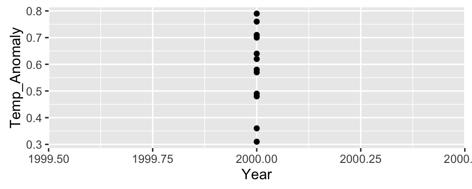

```r
#filtering the dataset to one year, to visualize lack of monthly resolution
test = filter(temps2, Year == 2000)
#plotting data
ggplot(data = test, aes(x = Year, y = Temp_Anomaly)) + geom_point()
```

This is because R doesn’t know that these points represent different dates within the year 2000. To do this, we need to convert our dates into a date format:

```r
#turning the Year and Month columns into a column that represents a specific date.
temps3 = temps2 %>% mutate(D = paste(Year, M, sep = ".")) %>% mutate(D2 = as_date(D))

#Looking at our new columns
head(temps3)
```

```
##   Year     M Temp_Anomaly          D         D2
## 1 1880 Jan.1        -0.79 1880.Jan.1 1880-01-01
## 2 1881 Jan.1        -0.76 1881.Jan.1 1881-01-01
## 3 1882 Jan.1         0.15 1882.Jan.1 1882-01-01
## 4 1883 Jan.1        -0.65 1883.Jan.1 1883-01-01
## 5 1884 Jan.1        -0.56 1884.Jan.1 1884-01-01
## 6 1885 Jan.1        -0.88 1885.Jan.1 1885-01-01
```

```r
#Extracting the month from the new date column and putting it into its own column. This is done to ensure that the month factor is ordered correctly (from January or 01 to December or 12).
temps4 = temps3 %>% mutate(M = month(D2))

#looking at our output
head(temps4)
```

```
##   Year M Temp_Anomaly          D         D2
## 1 1880 1        -0.79 1880.Jan.1 1880-01-01
## 2 1881 1        -0.76 1881.Jan.1 1881-01-01
## 3 1882 1         0.15 1882.Jan.1 1882-01-01
## 4 1883 1        -0.65 1883.Jan.1 1883-01-01
## 5 1884 1        -0.56 1884.Jan.1 1884-01-01
## 6 1885 1        -0.88 1885.Jan.1 1885-01-01
```